# Additional file 1

How accurate is altitude from pressure geolocators? Supplementary methods and results

Author

Raphaël Nussbaumer, Mathieu Gravey

This supplement describes the primary reference-data processes (S1), environmental variation (S2), the ERA5 product comparison (S3), reference-height checks (S4), station-selection sensitivity (S5), the bird-weighted summary (S6), and horizontal-position sensitivity (S7). It uses the main manuscript’s conversions and error definitions. Code and underlying numerical summaries accompany the analysis [1].

# S1 Reference-station selection and processing

## S1.1 GHCNh station selection

We use station pressures and reported elevations from NOAA’s Global Historical Climatology Network hourly archive (GHCNh) [2]. We select one station per represented grid cell through the process shown in Figure S1a. Here, an altitude discrepancy is the ERA5-standard estimate minus the reported station elevation.

1. **Group candidate stations.** We consider observations from 1 January 2022 through 12 October 2026 (UTC) and group stations into 200 × 200 km equal-area cells using the Equal Earth projection (EPSG:8857). Candidates must have coordinates, a reported elevation and data within this period. We assess them in random order within each cell.
2. **Assess candidates within each cell.** We select the first station that passes the following checks. If a candidate fails, we assess the next; if none passes, the cell remains unrepresented.
   - **2a. Prepare hourly observations.** We retain pressures between 300 and 1100 hPa that pass the source-quality exclusions.[^1] We assign each report to the nearest ERA5 hour and, where several reports share an hour, retain the one closest to it. We match these observations to surface pressure, 2 m temperature, dewpoint and orography at the nearest ERA5 grid cell, retaining observations with complete inputs.
   - **2b. Find a qualifying year.** We search backwards from the end of the study period in daily steps for the latest qualifying 12-month window. Within each window, we remove discrepancies more than both 100 m and ten scaled median absolute deviations (MAD) from its median. We then require at least 15 days with four accepted hours in each of the 12 month-long intervals measured backwards from the window endpoint. All remaining observations in the qualifying window are retained.
   - **2c. Check station consistency.** We reject a station if any of these conditions holds:
     - Extreme outliers account for more than 1% of the matched observations before their removal.
     - Its absolute mean discrepancy exceeds 30 m plus 10% of the absolute station–ERA5 elevation difference.
     - Its discrepancy shows a season-adjusted step of at least 10 m with an absolute step score of at least 10, or its history is insufficient for this check.[^2]
3. **Summarize errors.** We evaluate all three conversions using the same accepted observations.
   - **Station summaries.** We calculate each station’s mean signed error (bias) and SD, then summarize these metrics across stations with equal station weights.
   - **Observation summaries.** We calculate the median and 95th percentile of individual absolute errors from the pooled observations. Each station receives equal total weight, shared equally among its accepted hours.

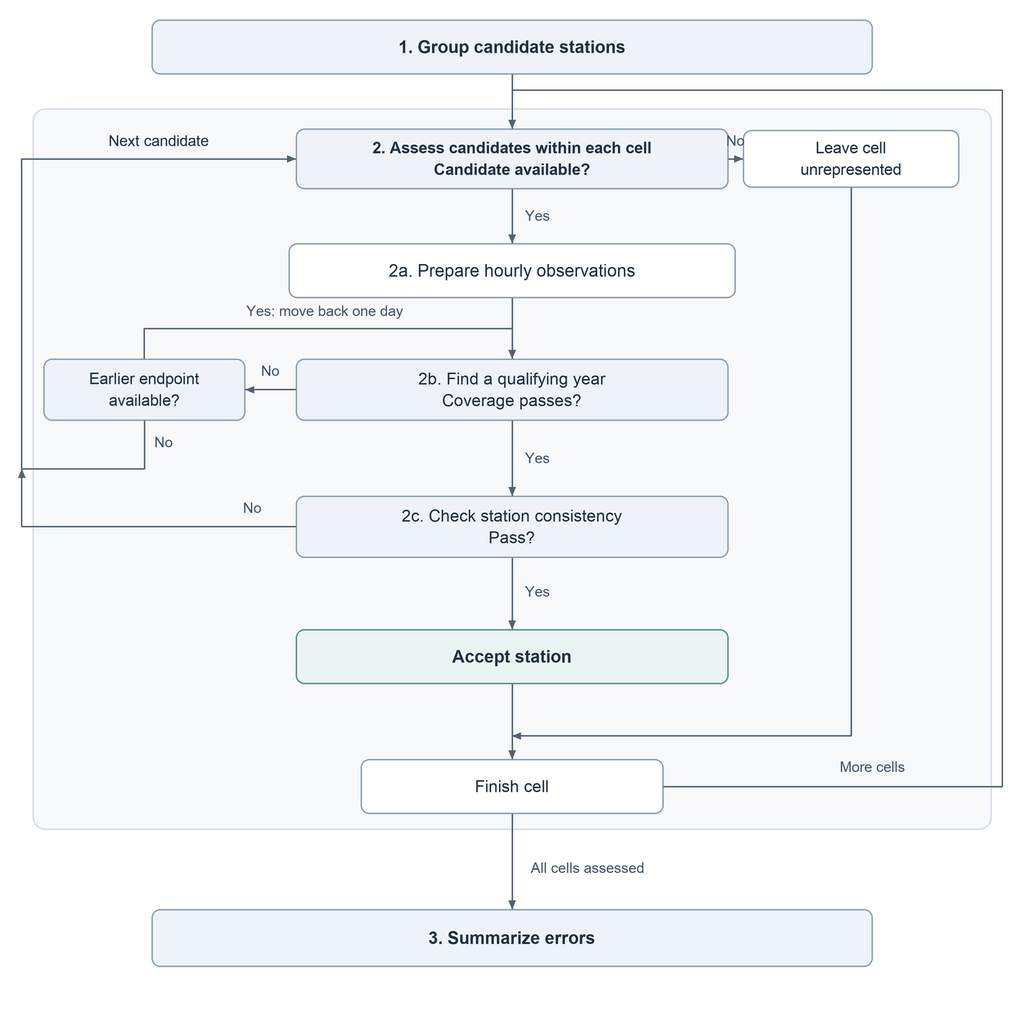

**Figure S1a.** GHCNh selection. The numbered boxes correspond to the steps above. An unsuccessful observation window moves the search back one day; a rejected candidate advances the search to the next station in its cell.

## S1.2 IGRA sounding selection

We use pressure and reported geopotential-height profiles from NOAA’s Integrated Global Radiosonde Archive (IGRA2) [3–5]. Each sounding includes a ground-level record at launch, which provides the surface reference for the ascent. Flight-height errors compare the estimated and reported height gain above this reference.

1. **Group candidate stations.** We use the study period and spatial grouping procedure in S1.1, assessing stations in random order within each cell (Figure S1b).
2. **Assess candidates within each cell.** We select the first station with a qualifying year of usable soundings. If a candidate fails, we assess the next; if none passes, the cell remains unrepresented.
   - **2a. Prepare sounding profiles.** We require a valid surface pressure and airborne pressure–height pairs up to 6 km above the launch surface. If the surface height is missing, we use the station elevation; we exclude soundings whose surface pressure or height was rejected by archive quality control. We match each airborne observation and its surface record separately to ERA5 using their observation times and the launch location. Reported launch and ascent times determine these times; missing launch times use the nominal time, and missing ascent times are estimated using a 5 m s$^{-1}$ ascent rate. We retain pairs with complete inputs for all three conversions.
   - **2b. Find a qualifying year.** We use the daily backwards search described in S1.1, assigning soundings to windows by launch time. Within each station and height band, we remove ERA5-standard errors more than both 150 m and ten scaled MAD from the window median. We then require at least 15 launch dates with an accepted airborne observation in each of the 12 month-long intervals. We retain all accepted airborne observations and their surface records from the latest qualifying window.
3. **Summarize errors.** We evaluate all three conversions using the same accepted observation pairs.
   - **Station summaries.** We calculate bias and SD within each station and height band, then summarize these metrics with equal weights among contributing stations.
   - **Observation summaries.** Within each height band, we calculate the median and 95th percentile of individual absolute errors. Each contributing station receives equal total weight, shared equally among its accepted airborne observations.

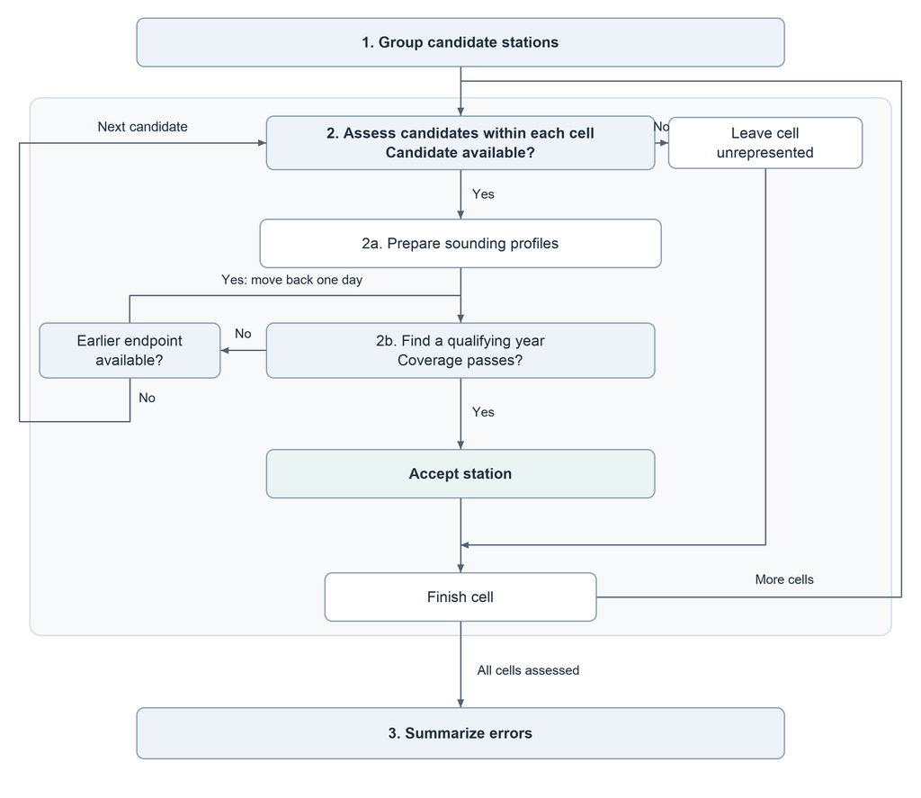

**Figure S1b.** IGRA selection. The numbered boxes correspond to the steps above. An unsuccessful observation window moves the search back one day; a rejected candidate advances the search to the next station in its cell.

# S2 How the error varies

## Ground: elevation gap, climate and time

The station–ERA5 elevation gap is associated with within-station scatter (Figure 1): fitted SD rises from 3.6 m at zero gap to 11.5 m at a 1000 m gap. This gap is distinct from terrain roughness, the sub-grid SD of orography used to classify terrain in the main manuscript. Seasonal, local-time and climate profiles provide context for the pooled ground summaries (Figure 2; Figure 3); the polar group has greater scatter.

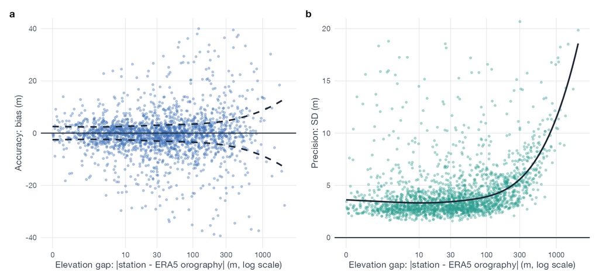

Figure 1: Bias (a) and SD (b) per station against the elevation gap between station and ERA5 orography (GHCNh reference set, ERA5 standard conversion). Dashed: ± fitted |bias|; solid: fitted SD. Equally weighted GAMs use log(|bias| + 0.5 m) or log(SD) as the response and a smooth of log(1 + absolute elevation gap); curves are back-transformed fits. Gap and error values inside logarithms are expressed numerically in metres.

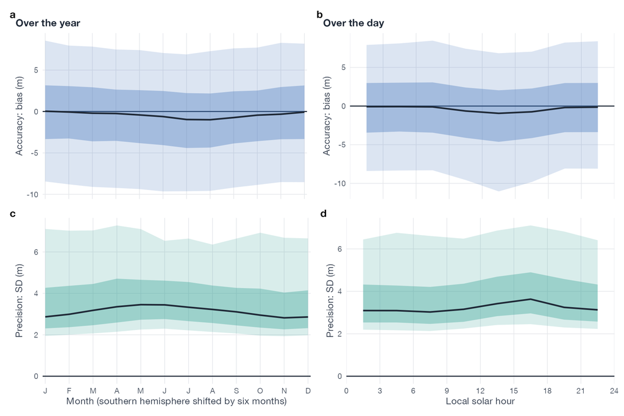

Figure 2: Station bias (a, b) and SD (c, d) by seasonal month (southern hemisphere shifted by six months) and 3 h local-solar-time band, screened GHCNh, ERA5 standard conversion. Station–time classes require at least 30 observations. Lines: equally weighted station medians; bands: station 25–75% and 10–90% ranges, rather than confidence intervals.

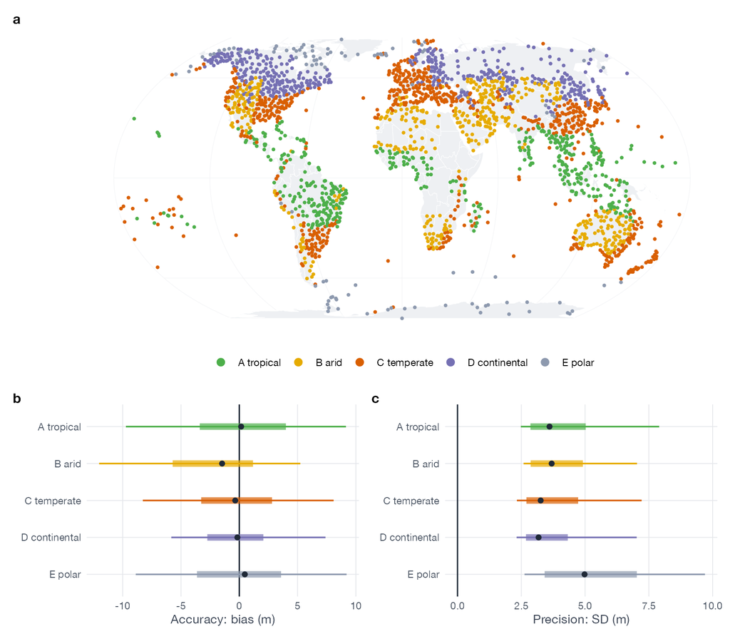

Figure 3: Ground errors by Köppen-Geiger climate zone, screened GHCNh, ERA5 standard conversion. (a) Station locations; (b) signed station bias; (c) within-station SD. Points: equally weighted station medians; thick and thin segments: 25–75% and 10–90% station ranges.

For a fixed historical comparison, we use 5 GHCNh stations with at least 500 usable observations in each of 1990, 2005, 2015 and 2024, calculating bias and SD separately by station and year (Figure 4). Their discrepancies decline across the sampled years, but this small common-station subset cannot establish a global accuracy trend.

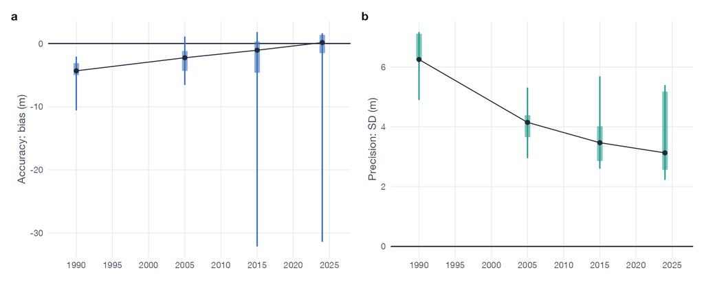

Figure 4: Station bias (a) and SD (b), ERA5 standard conversion, at the same five GHCNh stations in a fixed historical subset in 1990, 2005, 2015 and 2024 (at least 500 usable observations per station-year). Points: station medians; thick and thin segments: 25–75% and 10–90% station ranges; lines connect medians. The sample is descriptive and geographically restricted.

## Flight: climate, season and column temperature

Climate and half-year profiles show why a pooled signed error can conceal opposing biases (Figure 5). The corrected conversion reduces these seasonal biases, while a climatological lapse rate cannot reproduce every sounding’s profile. For ERA5 standard, the error predicted from the assumed versus observed mean column temperature closely follows the surface-referenced error (r = 0.98; Figure 6). Night-time underestimation is generally greater than daytime underestimation (Figure 7), consistent with surface inversions making the column warmer than the surface-based profile assumes.

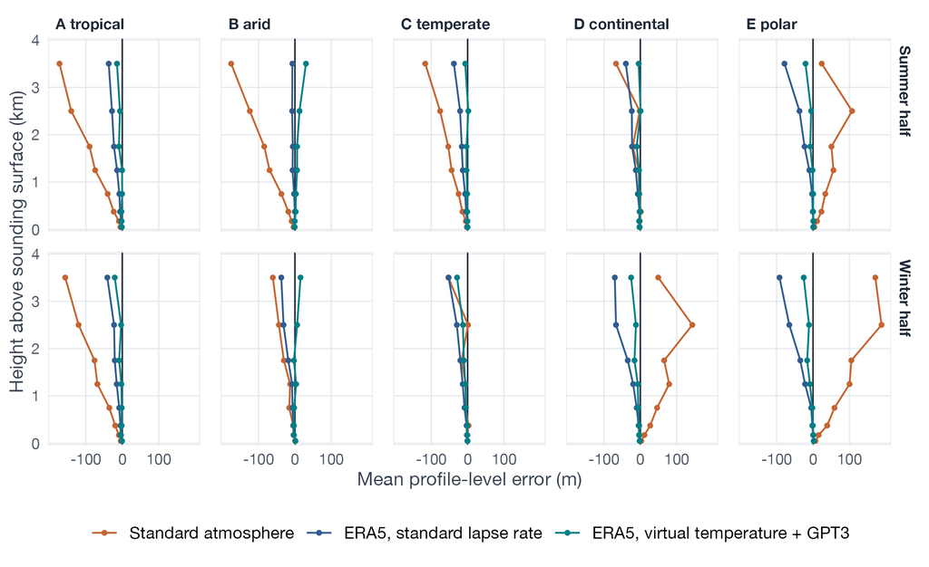

Figure 5: Mean signed surface-referenced profile-level error by conversion, Köppen-Geiger climate zone and half-year, shown to 4 km. These are pooled level summaries using the primary flight weights, rather than medians of station biases. Summer half is 21 March–22 September in the northern hemisphere and shifted by six months in the southern hemisphere; classes with fewer than three stations are omitted.

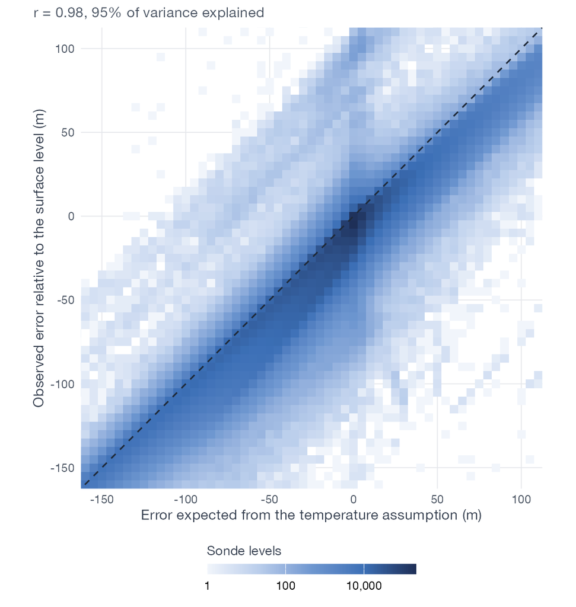

Figure 6: Observed surface-referenced flight-height error against the error predicted from the assumed versus observed mean column temperature, ERA5 standard conversion, at radiosonde levels more than 200 m above the sounding surface. Tile colour: number of levels (log scale); dashed line: 1:1 agreement. The displayed window is −150 to 100 m on both axes; the reported correlation uses the full retained comparison. Reported temperatures are integrated over log pressure, interpolating missing interior values and extending the lowest available temperature to the surface. This is a mechanism check using the same atmospheric profiles, rather than an independent validation.

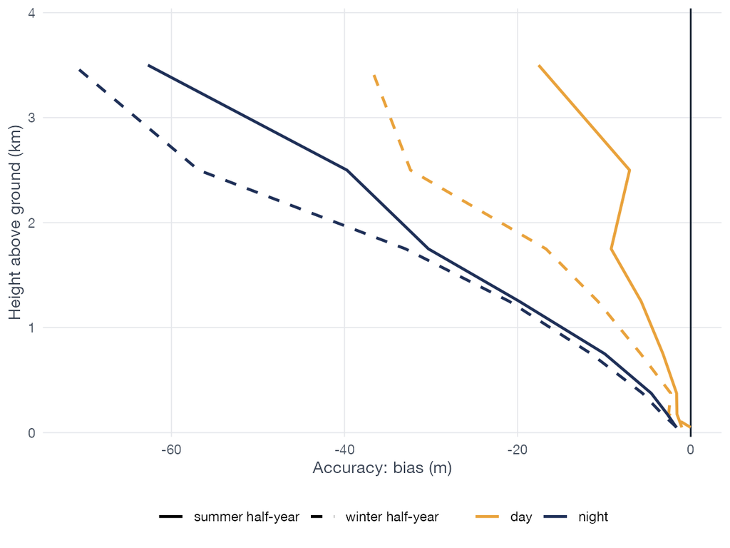

Figure 7: Mean signed surface-referenced profile-level error for ERA5 standard by day/night and half-year, shown to 4 km with the primary flight weights. Day is 07:00–19:00 local solar time; all other hours are night. Negative error indicates underestimated height. Half-years use the same hemispherically adjusted dates as the climate profiles; curves join observed height-band summaries.

# S3 ERA5 single-levels and ERA5-Land

ERA5-Land’s finer 0.1° grid [6] does not reduce persistent ground offsets in these comparisons. Median station |bias| is 10.4 m versus 3.1 m for ERA5 single-levels at the 1772 GHCNh stations with usable inputs for both products, with the same ordering at GNSS and MeteoSwiss stations (Figure 8). Surface-referenced flight errors are similar (Figure 9). Together, these results point to a difference in the surface reference; they do not by themselves identify an inconsistency in ERA5-Land’s pressure adjustment or published orography.

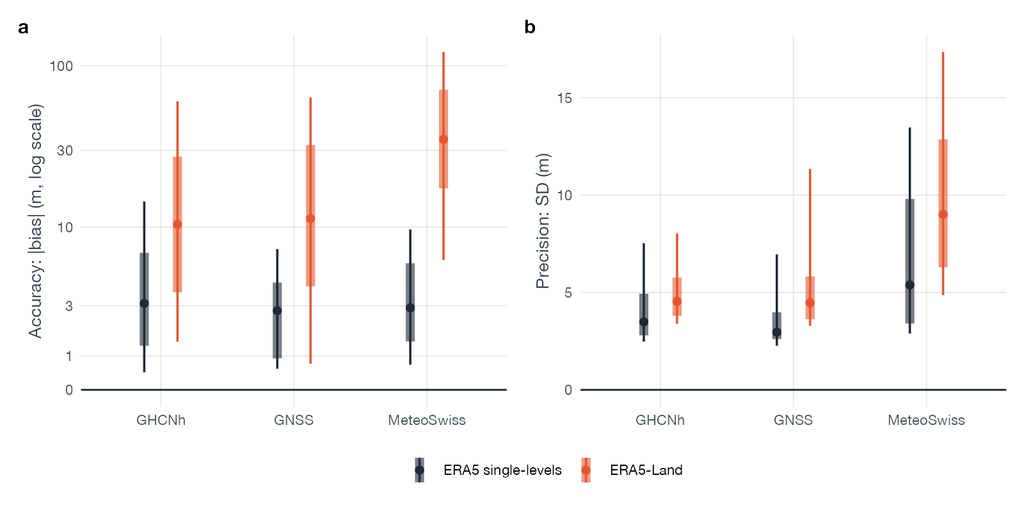

Figure 8: Station |bias| (a, pseudo-log scale) and SD (b) with ERA5 single-levels and ERA5-Land, using the standard lapse rate at the same stations within each ground reference. Comparisons use the same hours with finite inputs for both products. Points: weighted station medians; thick and thin segments: 25–75% and 10–90% station ranges. Each station contributes equally within its reference network.

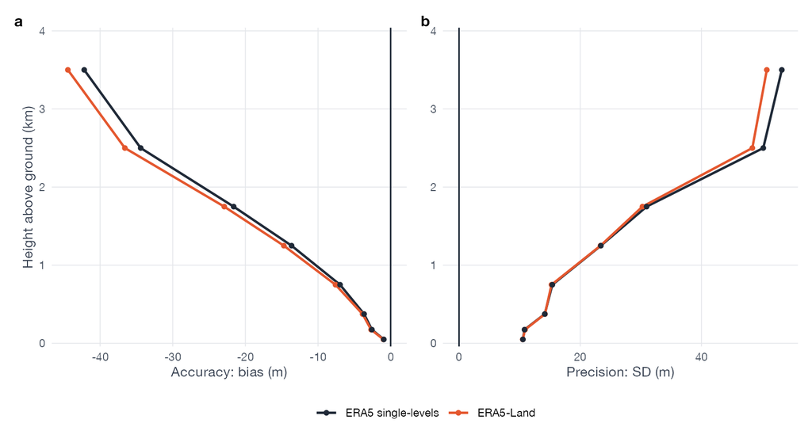

Figure 9: Pooled surface-referenced flight-height bias (a) and SD (b) by height band, ERA5 single-levels versus ERA5-Land with the standard lapse rate. The comparison uses levels with finite inputs for both products, with equal station weight within each band, and is shown to 4 km. Pooled SD includes between-station differences and differs from the median within-station SD in the main manuscript.

# S4 Reference-height checks

Listed station elevation can differ from the height of the pressure sensor [7, 8]. We examine this directly at matched Swiss stations and compare ground errors with two references that provide more explicit sensor-height information.

## Paired Swiss height comparison

At 3 stations matched by WMO identifier and coordinates within 1 km, we replace the listed GHCNh elevation with the published MeteoSwiss barometer height while holding the GHCNh pressures, ERA5 inputs and observation window fixed. Median station |bias| changes from 1.6 to 1.4 m (Table 1). This small paired comparison illustrates sensitivity to the height reference at these sites.

Table 1: Paired height-reference comparison at retained GHCNh stations matched to MeteoSwiss. Both errors use the same GHCNh pressure reports, ERA5 inputs and observation window. Heights and absolute station biases are in metres.

| Station (WMO) | Listed height | Sensor height | \|bias\|, listed | \|bias\|, sensor |
| --- | --- | --- | --- | --- |
| 06606 | 431.0 | 431.0 | 0.1 | 0.1 |
| 06645 | 610.0 | 613.0 | 1.6 | 1.4 |
| 06722 | 1828.0 | 1829.0 | 9.6 | 8.6 |

## Barometers at GNSS and MeteoSwiss stations

For GNSS stations, we use RINEX meteorological records from the IGS/EUREF archives in 2022–2024 [9, 10]. Samples within one minute of each hour are averaged into unique station-hours. Sensor heights combine site-log marker and antenna heights with barometer offsets, converted from ellipsoidal height using EGM96; file-header heights fill gaps in the site-log record. We require at least 180 listed file-days, 2160 accepted hours and a median signed difference within 1 m between the file-header and site-log heights. The height check establishes metadata consistency.

For MeteoSwiss SwissMetNet, we use full-hour pressure observations in 2022–2024 at published barometer heights, retaining stations with at least 2160 accepted hours [11]. Published sea-level heights are used without a Swiss-to-EGM96 transformation. For both references, we exclude ERA5-standard errors more than both 100 m and ten scaled MAD from the station median before applying the accepted-hour requirement. We use equal station weights for the individual-error summaries (Table 2).

The networks differ in geography, observation periods and sensor metadata. Their pooled errors provide corroboration; the paired Swiss height comparison isolates the effect of changing the height reference. Neither comparison establishes independence from ERA5 assimilation.

Table 2: Ground errors at references with more explicit pressure-sensor heights, ERA5 standard conversion (m). Bias and SD are station metrics; median absolute error and p95 describe weighted individual observations.

| Reference | Stations | Median \|bias\| | Median SD | Median \|error\| | p95 |
| --- | --- | --- | --- | --- | --- |
| GNSS | 49 | 2.4 | 3.0 | 3.0 | 19.2 |
| MeteoSwiss | 138 | 2.9 | 5.4 | 4.2 | 22.8 |

# S5 Effect of station selection

The GHCNh station checks use ERA5-standard discrepancies and can exclude model discrepancies as well as suspect reference records. We compare the primary selection with selection based on accepted coverage alone to assess how these checks affect the reported errors.

Within each cell represented by the primary sample, both selections follow the same random candidate order. The primary selection retains the first station passing all checks; the coverage-only selection retains the first station with a qualifying observation window. Observation-level quality exclusions and the represented cells are held fixed, while the selected stations may differ. Each station receives equal weight, divided among its accepted observations. Table 3 reports the resulting individual-error summaries for all three conversions.

Table 3: Effect of GHCNh station checks within the cells represented by the primary sample. Both selections retain one station per cell and apply the same observation-level exclusions. Errors are in metres.

| Selection | Conversion | Stations | Median \|error\| | p95 |
| --- | --- | --- | --- | --- |
| Primary | Standard atm. | 2130 | 40.3 | 147.6 |
| Coverage only | Standard atm. | 2130 | 40.8 | 151.9 |
| Primary | ERA5 standard | 2130 | 4.1 | 23.4 |
| Coverage only | ERA5 standard | 2130 | 4.2 | 27.4 |
| Primary | ERA5 virtual + GPT3 | 2130 | 4.1 | 23.5 |
| Coverage only | ERA5 virtual + GPT3 | 2130 | 4.2 | 27.4 |

For ERA5 standard, median absolute error is 4.1 m with the primary checks and 4.2 m with coverage alone; the corresponding 95th percentiles are 23.4 and 27.4 m. The checks mainly affect the error tail in this comparison.

# S6 Bird-weighted flight-height summary

We estimate the flight-time height distribution from 203 tagged birds of 25 species in the Master GeoLocator Data Package [12], using its supplied flight classifications. Each record represents the interval to the next record, capped at one hour. Heights are calculated from tag pressure relative to ERA5 surface pressure using 288.15 K and the standard lapse rate. Pressure offsets are interpolated between adjacent stationary periods. Negative estimates enter the lowest height band and estimates above 6 km enter the highest evaluated band. These pressure-derived heights determine the weights; they do not establish true terrain clearance.

Within each height band, stations contribute equally to the radiosonde error distribution. We then weight each band’s distribution by its share of bird flight time and calculate the median of the combined absolute-error distribution. Main Figure 4c shows the biological height distribution. As a focused robustness check, we repeat the calculation giving every contributing tag equal total weight (Table 4), assessing whether extensively sampled birds dominate the summary.

Table 4: Bird-weighted median absolute flight-height error (m), comparing pooled flight-time weights with equal total weight per tag. Both calculations use the same flight records and radiosonde inputs.

| Target | Standard atm. | ERA5 standard | ERA5 virtual + GPT3 |
| --- | --- | --- | --- |
| Flight time | 20.6 | 6.9 | 5.5 |
| Equal tag | 17.7 | 6.2 | 5.0 |

# S7 Sensitivity to horizontal position

**Design.** We shift the ERA5/GPT3 query position, keeping pressure, time and radiosonde reference height fixed. The fixed-seed pilot samples ten IGRA2 stations across five climate zones and two terrain strata (<100 or $\geq 100$ m sub-grid orography SD; six northern and four southern stations). Each supplies two eligible launches nearest mid-quarter per quarter of 2024, using the level nearest 2 km (within 1.7–2.3 km) and its surface record. Displacements are 0, 10, 25, 50, 100 and 200 km, with eight bearings at positive distances. Small shifts can select the same ERA5 cell; the standard atmosphere is location-independent.

**Interpretation.** Absolute altitude and surface-referenced flight height respond differently (Figure 10). The latter subtracts the surface error at the same displaced position and original surface-observation time. Small changes in pooled median error can conceal larger individual paired changes (Table 5). This fixed-height pilot does not establish a global location-error distribution or acceptable displacement radius, and excludes terrain-clearance uncertainty, balloon drift, moving anchors and rare weather extremes.

Table 5: Atmospheric-query displacement with ERA5 virtual + GPT3 near 2 km (all errors in metres). Median error change is displaced minus exact-location median absolute error. Paired median and p95 summarize absolute changes between matched displaced and exact-location errors. Stations, launches and bearings receive equal weights.

| Outcome | Distance (km) | Median error change | Paired median | Paired p95 |
| --- | --- | --- | --- | --- |
| Absolute altitude | 50 | 0.2 | 5.1 | 21.1 |
| Absolute altitude | 200 | 4.2 | 12.5 | 54.1 |
| Flight height | 50 | -1.1 | 4.9 | 22.6 |
| Flight height | 200 | 0.6 | 11.5 | 48.0 |

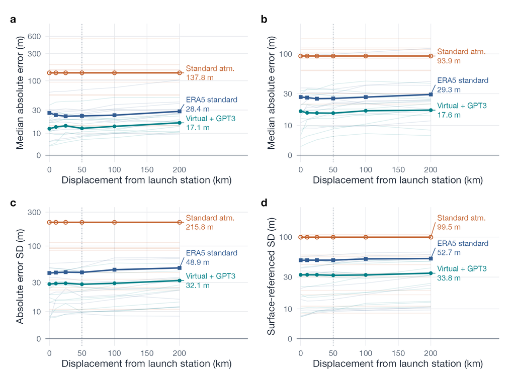

Figure 10: Error versus nominal displacement of the atmospheric query from the launch station. Left: absolute altitude near 2 km above the sounding surface; right: height after subtracting the displaced surface error. Upper panels: median absolute error; lower panels: pooled error SD. Faint curves: individual stations; strong curves and markers: pooled pilot (10 stations, 80 soundings, eight bearings per positive distance). Direct labels give pooled values at 200 km. The dotted vertical guide marks 50 km. Curves join evaluated distances without smoothing. All vertical axes use a pseudo-log scale (linear close to zero) so the station traces and pooled summaries remain visible together. Pooled SD includes between-station offsets; station scatter is empirical variation, not a confidence interval.

# References

1. Nussbaumer R, Gravey M. How accurate is altitude from pressure geolocators? Code, data and report. 2026. https://doi.org/10.5281/zenodo.23085093.

2. NOAA National Centers for Environmental Information. [Global historical climatology network hourly (GHCNh)](https://www.ncei.noaa.gov/products/global-historical-climatology-network-hourly). 2026.

3. Durre I, Vose RS, Wuertz DB. Overview of the Integrated Global Radiosonde Archive. Journal of Climate. 2006;19:53–68. https://doi.org/10.1175/JCLI3594.1.

4. Durre I, Yin X, Vose RS, et al. Enhancing the data coverage in the Integrated Global Radiosonde Archive. Journal of Atmospheric and Oceanic Technology. 2018;35:1753–70. https://doi.org/10.1175/JTECH-D-17-0223.1.

5. NOAA National Centers for Environmental Information. [Integrated global radiosonde archive: Product and sounding-format documentation](https://www.ncei.noaa.gov/products/weather-balloon/integrated-global-radiosonde-archive).

6. Muñoz-Sabater J, Dutra E, Agustí-Panareda A, et al. ERA5-Land: A state-of-the-art global reanalysis dataset for land applications. Earth System Science Data. 2021;13:4349–83. https://doi.org/10.5194/essd-13-4349-2021.

7. Vasiljevic D, Andersson E, Isaksen L, Garcia-Mendez A. Surface pressure bias correction in data assimilation. ECMWF Newsletter. 2006;108:20–7. https://doi.org/10.21957/uv295rfmx5.

8. Haiden T, Dahoui M, Ingleby B, et al. [Use of in situ surface observations at ECMWF](https://www.ecmwf.int/sites/default/files/elibrary/2018/80920-use-situ-surface-observations-ecmwf.pdf). Technical Memorandum. ECMWF; 2018.

9. Federal Agency for Cartography and Geodesy. [BKG GNSS Data Center: Data and product holdings](https://igs.bkg.bund.de/holdings).

10. IGS RINEX Working Group, RTCM-SC104. [RINEX: The receiver independent exchange format, version 3.04](https://files.igs.org/pub/data/format/rinex304.pdf). 2018.

11. MeteoSwiss. [Automatic weather stations: Open data documentation](https://opendatadocs.meteoswiss.ch/a-data-groundbased/a1-automatic-weather-stations).

12. Nussbaumer R, Adamik P, Alerstam T, Andersson A, Arlettaz R, Bächler E, et al. Master GeoLocator data package. 2026. https://doi.org/10.5281/zenodo.18187093.

## Footnotes

[^1]: We exclude pressures identified as suspect, erroneous, removed or failing archive checks according to NOAA’s [source-specific quality-code definitions](https://www.ncei.noaa.gov/oa/global-historical-climatology-network/hourly/doc/ghcnh_DOCUMENTATION.pdf). Other and missing quality codes are retained.
[^2]: A step is a persistent shift in discrepancy after accounting for seasonality. We use up to three years ending at the selected window endpoint and apply the outlier rule to this history. We calculate calendar-month medians from months with at least 60 accepted hours and require at least 18 medians spanning all 12 calendar months. We fit month-of-year effects and a single shift, choosing the breakpoint within the selected window that minimizes residual variation, with at least three monthly medians on each side. The step score is the fitted shift divided by its standard error; it serves as a screening score rather than a calibrated significance test.